# Travel Package Purchase Prediction

## Travel Package Purchase Prediction

### Background and Context

A company named "Visit with us" is updating its business model. The Policy Maker of the company wants to establish a viable business model to expand the customer base.

A viable business model is a central concept that helps to understand the existing ways of doing business and ways in which the business could be updated to benefit the tourism sector.

One of the ways to expand the customer base is to introduce new offering of packages.

Currently, there are 5 types of packages the company is offering - Basic, Standard, Deluxe, Super Deluxe, King. Looking at last year's data, it was observed that 18% of the customers purchased the packages.

However, it was difficult to identify the potential customers because customers were contacted at random without looking at the available information.

The company is now planning to launch a new product i.e. Wellness Tourism Package. Wellness Tourism is defined as Travel that allows the traveler to maintain, enhance or kick-start a healthy lifestyle, and support or increase one's sense of well-being.

This time the company wants to harness available data of existing and potential customers to target the right customers.

The purpose of this case study is to analyze existing customers' data and build a model to predict potential customers who will purchase the newly introduced travel package and provide recommendations to the Policy Maker. The model will be built to make predictions before a customer is contacted.

### Objective

To predict which customer is more likely to purchase the newly introduced travel package.

### Data Dictionary

#### Customer details:

- CustomerID: Unique customer ID
- ProdTaken: Whether the customer has purchased a package or not (0: No, 1: Yes)
- Age: Age of customer
- TypeofContact: How customer was contacted (Company Invited or Self Inquiry)
- CityTier: City tier depends on the development of a city, population, facilities, and living standards. The categories are ordered i.e. Tier 1 > Tier 2 > Tier 3. It's the city the customer lives in.
- Occupation: Occupation of customer
- Gender: Gender of customer
- NumberOfPersonVisiting: Total number of persons planning to take the trip with the customer
- PreferredPropertyStar: Preferred hotel property rating by customer
- MaritalStatus: Marital status of customer
- NumberOfTrips: Average number of trips in a year by customer
- Passport: The customer has a passport or not (0: No, 1: Yes)
- OwnCar: Whether the customers own a car or not (0: No, 1: Yes)
- NumberOfChildrenVisiting: Total number of children with age less than 5 planning to take the trip with the customer
- Designation: Designation of the customer in the current organization
- MonthlyIncome: Gross monthly income of the customer

#### Customer interaction data:

- PitchSatisfactionScore: Sales pitch satisfaction score
- ProductPitched: Product pitched by the salesperson
- NumberOfFollowups: Total number of follow-ups has been done by the salesperson after the sales pitch
- DurationOfPitch: Duration of the pitch by a salesperson to the customer

```python
# Library to suppress warnings or deprecation notes
import warnings
warnings.filterwarnings('ignore')

# Libraries to help with reading and manipulating data
import numpy as np
import pandas as pd

# Libraries to help with data visualization
import matplotlib.pyplot as plt
%matplotlib inline
import seaborn as sns

# Libraries to split data, impute missing values
from sklearn.model_selection import train_test_split
from sklearn.impute import SimpleImputer

# Libraries to import decision tree classifier and different ensemble classifiers
from sklearn.ensemble import BaggingClassifier
from sklearn.ensemble import RandomForestClassifier
from sklearn.ensemble import AdaBoostClassifier, GradientBoostingClassifier
from xgboost import XGBClassifier
from sklearn.ensemble import StackingClassifier
from sklearn.tree import DecisionTreeClassifier

# Libtune to tune model, get different metric scores
from sklearn import metrics
from sklearn.metrics import confusion_matrix, classification_report, accuracy_score, precision_score, recall_score, f1_score, roc_auc_score
from sklearn.model_selection import GridSearchCV
```

### Define functions needed for data analysis

```python
# function to plot a boxplot and a histogram along the same scale.


def histogram_boxplot(data, feature, figsize=(12, 7), kde=False, bins=None):
    """
    Boxplot and histogram combined

    data: dataframe
    feature: dataframe column
    figsize: size of figure (default (12,7))
    kde: whether to the show density curve (default False)
    bins: number of bins for histogram (default None)
    """
    f2, (ax_box2, ax_hist2) = plt.subplots(
        nrows=2,  # Number of rows of the subplot grid= 2
        sharex=True,  # x-axis will be shared among all subplots
        gridspec_kw={"height_ratios": (0.25, 0.75)},
        figsize=figsize,
    )  # creating the 2 subplots
    sns.boxplot(
        data=data, x=feature, ax=ax_box2, showmeans=True, color="violet"
    )  # boxplot will be created and a star will indicate the mean value of the column
    sns.histplot(
        data=data, x=feature, kde=kde, ax=ax_hist2, bins=bins, palette="winter"
    ) if bins else sns.histplot(
        data=data, x=feature, kde=kde, ax=ax_hist2
    )  # For histogram
    ax_hist2.axvline(
        data[feature].mean(), color="green", linestyle="--"
    )  # Add mean to the histogram
    ax_hist2.axvline(
        data[feature].median(), color="black", linestyle="-"
    )  # Add median to the histogram
```

```python
# function to create labeled barplots


def labeled_barplot(data, feature, perc=False, n=None):
    """
    Barplot with percentage at the top

    data: dataframe
    feature: dataframe column
    perc: whether to display percentages instead of count (default is False)
    n: displays the top n category levels (default is None, i.e., display all levels)
    """

    total = len(data[feature])  # length of the column
    count = data[feature].nunique()
    if n is None:
        plt.figure(figsize=(count + 1, 5))
    else:
        plt.figure(figsize=(n + 1, 5))

    plt.xticks(rotation=90, fontsize=15)
    ax = sns.countplot(
        data=data,
        x=feature,
        palette="Paired",
        order=data[feature].value_counts().index[:n].sort_values(),
    )

    for p in ax.patches:
        if perc == True:
            label = "{:.1f}%".format(
                100 * p.get_height() / total
            )  # percentage of each class of the category
        else:
            label = p.get_height()  # count of each level of the category

        x = p.get_x() + p.get_width() / 2  # width of the plot
        y = p.get_height()  # height of the plot

        ax.annotate(
            label,
            (x, y),
            ha="center",
            va="center",
            size=12,
            xytext=(0, 5),
            textcoords="offset points",
        )  # annotate the percentage

    plt.show()  # show the plot
```

```python
def stacked_barplot(data, predictor, target):

    """
    Print the category counts and plot a stacked bar chart

    data: dataframe
    predictor: independent variable
    target: target variable
    """
    count = data[predictor].nunique()
    sorter = data[target].value_counts().index[-1]
    tab1 = pd.crosstab(data[predictor], data[target], margins=True).sort_values(
        by=sorter, ascending=False
    )
    print(tab1)
    print("-" * 120)
    tab = pd.crosstab(data[predictor], data[target], normalize="index").sort_values(
        by=sorter, ascending=False
    )
    tab.plot(kind="bar", stacked=True, figsize=(count + 5, 5))
    plt.legend(
        loc="lower left", frameon=False,
    )
    plt.legend(loc="upper left", bbox_to_anchor=(1, 1))
    plt.show()
```

### Read the dataset

```python
travel = pd.read_excel("Tourism.xlsx", sheet_name="Tourism")
# copying data to another varaible to avoid any changes to original data
data = travel.copy()
```

### View the head, tail and random sample of the data set

```python
#view the first 5 rows of the dataset
data.head()
```

|  | CustomerID | ProdTaken | Age | TypeofContact | CityTier | DurationOfPitch | Occupation | Gender | NumberOfPersonVisiting | NumberOfFollowups | ProductPitched | PreferredPropertyStar | MaritalStatus | NumberOfTrips | Passport | PitchSatisfactionScore | OwnCar | NumberOfChildrenVisiting | Designation | MonthlyIncome |
| --- | --- | --- | --- | --- | --- | --- | --- | --- | --- | --- | --- | --- | --- | --- | --- | --- | --- | --- | --- | --- |
| 0 | 200000 | 1 | 41.0 | Self Enquiry | 3 | 6.0 | Salaried | Female | 3 | 3.0 | Deluxe | 3.0 | Single | 1.0 | 1 | 2 | 1 | 0.0 | Manager | 20993.0 |
| 1 | 200001 | 0 | 49.0 | Company Invited | 1 | 14.0 | Salaried | Male | 3 | 4.0 | Deluxe | 4.0 | Divorced | 2.0 | 0 | 3 | 1 | 2.0 | Manager | 20130.0 |
| 2 | 200002 | 1 | 37.0 | Self Enquiry | 1 | 8.0 | Free Lancer | Male | 3 | 4.0 | Basic | 3.0 | Single | 7.0 | 1 | 3 | 0 | 0.0 | Executive | 17090.0 |
| 3 | 200003 | 0 | 33.0 | Company Invited | 1 | 9.0 | Salaried | Female | 2 | 3.0 | Basic | 3.0 | Divorced | 2.0 | 1 | 5 | 1 | 1.0 | Executive | 17909.0 |
| 4 | 200004 | 0 | NaN | Self Enquiry | 1 | 8.0 | Small Business | Male | 2 | 3.0 | Basic | 4.0 | Divorced | 1.0 | 0 | 5 | 1 | 0.0 | Executive | 18468.0 |

```python
#view the last 5 rows of the dataset
data.tail()
```

|  | CustomerID | ProdTaken | Age | TypeofContact | CityTier | DurationOfPitch | Occupation | Gender | NumberOfPersonVisiting | NumberOfFollowups | ProductPitched | PreferredPropertyStar | MaritalStatus | NumberOfTrips | Passport | PitchSatisfactionScore | OwnCar | NumberOfChildrenVisiting | Designation | MonthlyIncome |
| --- | --- | --- | --- | --- | --- | --- | --- | --- | --- | --- | --- | --- | --- | --- | --- | --- | --- | --- | --- | --- |
| 4883 | 204883 | 1 | 49.0 | Self Enquiry | 3 | 9.0 | Small Business | Male | 3 | 5.0 | Deluxe | 4.0 | Unmarried | 2.0 | 1 | 1 | 1 | 1.0 | Manager | 26576.0 |
| 4884 | 204884 | 1 | 28.0 | Company Invited | 1 | 31.0 | Salaried | Male | 4 | 5.0 | Basic | 3.0 | Single | 3.0 | 1 | 3 | 1 | 2.0 | Executive | 21212.0 |
| 4885 | 204885 | 1 | 52.0 | Self Enquiry | 3 | 17.0 | Salaried | Female | 4 | 4.0 | Standard | 4.0 | Married | 7.0 | 0 | 1 | 1 | 3.0 | Senior Manager | 31820.0 |
| 4886 | 204886 | 1 | 19.0 | Self Enquiry | 3 | 16.0 | Small Business | Male | 3 | 4.0 | Basic | 3.0 | Single | 3.0 | 0 | 5 | 0 | 2.0 | Executive | 20289.0 |
| 4887 | 204887 | 1 | 36.0 | Self Enquiry | 1 | 14.0 | Salaried | Male | 4 | 4.0 | Basic | 4.0 | Unmarried | 3.0 | 1 | 3 | 1 | 2.0 | Executive | 24041.0 |

```python
# view a radom sample of the dataset 0f 10 rows
data.sample(n=10, random_state=1)
```

|  | CustomerID | ProdTaken | Age | TypeofContact | CityTier | DurationOfPitch | Occupation | Gender | NumberOfPersonVisiting | NumberOfFollowups | ProductPitched | PreferredPropertyStar | MaritalStatus | NumberOfTrips | Passport | PitchSatisfactionScore | OwnCar | NumberOfChildrenVisiting | Designation | MonthlyIncome |
| --- | --- | --- | --- | --- | --- | --- | --- | --- | --- | --- | --- | --- | --- | --- | --- | --- | --- | --- | --- | --- |
| 3015 | 203015 | 0 | 27.0 | Company Invited | 1 | 7.0 | Salaried | Female | 4 | 6.0 | Basic | 3.0 | Married | 5.0 | 0 | 4 | 1 | 3.0 | Executive | 23042.0 |
| 1242 | 201242 | 0 | 40.0 | Self Enquiry | 3 | 13.0 | Small Business | Male | 2 | 3.0 | King | 4.0 | Single | 2.0 | 0 | 4 | 1 | NaN | VP | 34833.0 |
| 3073 | 203073 | 0 | 29.0 | Self Enquiry | 2 | 15.0 | Small Business | Male | 4 | 5.0 | Basic | 3.0 | Married | 3.0 | 0 | 2 | 0 | 2.0 | Executive | 23614.0 |
| 804 | 200804 | 0 | 48.0 | Company Invited | 1 | 6.0 | Small Business | Male | 2 | 1.0 | Super Deluxe | 3.0 | Single | 3.0 | 0 | 2 | 0 | 0.0 | AVP | 31885.0 |
| 3339 | 203339 | 0 | 32.0 | Self Enquiry | 1 | 18.0 | Small Business | Male | 4 | 4.0 | Deluxe | 5.0 | Divorced | 3.0 | 1 | 2 | 0 | 3.0 | Manager | 25511.0 |
| 3080 | 203080 | 1 | 36.0 | Company Invited | 1 | 32.0 | Salaried | Female | 4 | 4.0 | Basic | 4.0 | Married | 3.0 | 1 | 3 | 0 | 1.0 | Executive | 20700.0 |
| 2851 | 202851 | 0 | 46.0 | Self Enquiry | 1 | 17.0 | Salaried | Male | 4 | 4.0 | Basic | 3.0 | Divorced | 5.0 | 0 | 5 | 1 | 1.0 | Executive | 21332.0 |
| 2883 | 202883 | 1 | 32.0 | Company Invited | 1 | 27.0 | Salaried | Male | 4 | 4.0 | Standard | 3.0 | Divorced | 5.0 | 0 | 3 | 1 | 1.0 | Senior Manager | 28502.0 |
| 1676 | 201676 | 0 | 22.0 | Self Enquiry | 1 | 11.0 | Salaried | Male | 2 | 1.0 | Basic | 4.0 | Married | 2.0 | 1 | 4 | 1 | 0.0 | Executive | 17328.0 |
| 1140 | 201140 | 0 | 44.0 | Self Enquiry | 1 | 13.0 | Small Business | Female | 2 | 3.0 | King | 3.0 | Married | 1.0 | 1 | 4 | 1 | 1.0 | VP | 34049.0 |

```python
# checking the shape of the data
print(f"There are {data.shape[0]} rows and {data.shape[1]} columns.")  # f-string
```

```
There are 4888 rows and 20 columns.
```

```python
#Check  for dupliucate values
data.duplicated().sum()
print(f"There are {data.duplicated().sum()} duplicate rows.")  # f-string
```

```
There are 0 duplicate rows.
```

### Check the data types of the columns for the dataset.

```python
data.info()
```

```
<class 'pandas.core.frame.DataFrame'>
RangeIndex: 4888 entries, 0 to 4887
Data columns (total 20 columns):
 #   Column                    Non-Null Count  Dtype
---  ------                    --------------  -----
 0   CustomerID                4888 non-null   int64
 1   ProdTaken                 4888 non-null   int64
 2   Age                       4662 non-null   float64
 3   TypeofContact             4863 non-null   object
 4   CityTier                  4888 non-null   int64
 5   DurationOfPitch           4637 non-null   float64
 6   Occupation                4888 non-null   object
 7   Gender                    4888 non-null   object
 8   NumberOfPersonVisiting    4888 non-null   int64
 9   NumberOfFollowups         4843 non-null   float64
 10  ProductPitched            4888 non-null   object
 11  PreferredPropertyStar     4862 non-null   float64
 12  MaritalStatus             4888 non-null   object
 13  NumberOfTrips             4748 non-null   float64
 14  Passport                  4888 non-null   int64
 15  PitchSatisfactionScore    4888 non-null   int64
 16  OwnCar                    4888 non-null   int64
 17  NumberOfChildrenVisiting  4822 non-null   float64
 18  Designation               4888 non-null   object
 19  MonthlyIncome             4655 non-null   float64
dtypes: float64(7), int64(7), object(6)
memory usage: 763.9+ KB
```

There are 20 columns, most of the columns are int or float. There are 6 columns that are of object data type. These columns are : TypeofContact, Occupation, Gender, ProductPitched, MaritalStatus and Designation. We can look into value counts to see if some of the columns can be made categorical. There are null values in a few columns that we would have to look at.

## Feature Engineering

### Looking at unique values for data

```python
# Print the unique values for each column
for i in data.columns:
    n = len(pd.unique(data[i]))
    print(i, n)
```

```
CustomerID 4888
ProdTaken 2
Age 45
TypeofContact 3
CityTier 3
DurationOfPitch 35
Occupation 4
Gender 3
NumberOfPersonVisiting 5
NumberOfFollowups 7
ProductPitched 5
PreferredPropertyStar 4
MaritalStatus 4
NumberOfTrips 13
Passport 2
PitchSatisfactionScore 5
OwnCar 2
NumberOfChildrenVisiting 5
Designation 5
MonthlyIncome 2476
```

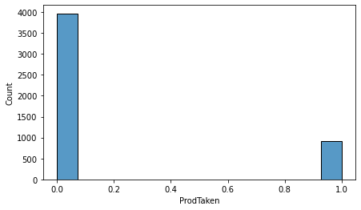

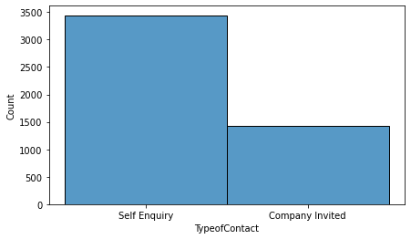

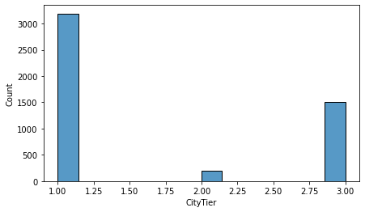

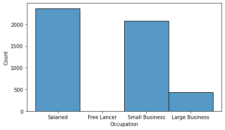

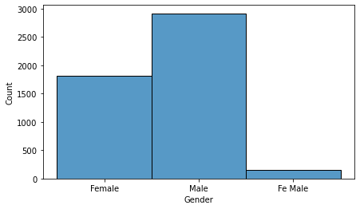

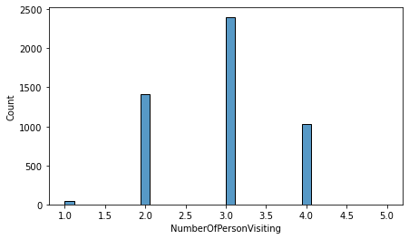

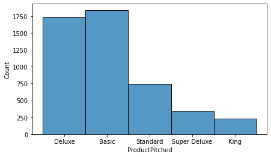

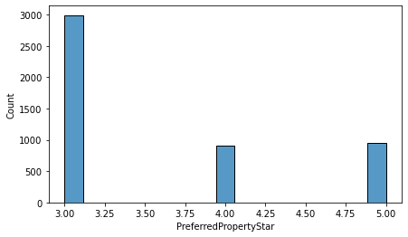

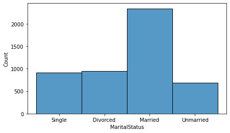

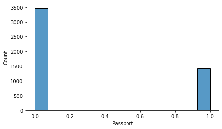

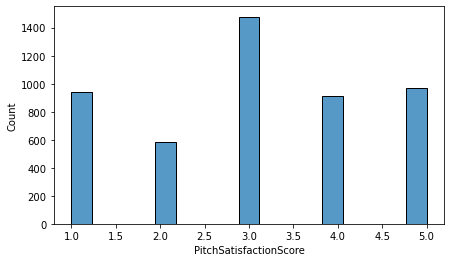

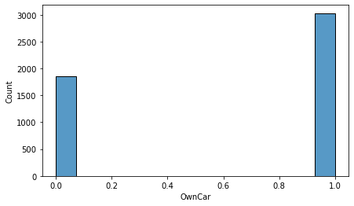

[2 more figures not shown]

```python
#Printing histplot for columns who have less than or equal to 5 unique values
#to see if they are good candidates for categorical variables.
for i in data.columns:
    n = len(pd.unique(data[i]))

    if n <= 5:
        plt.figure(figsize=(7, 4))
        sns.histplot(data=data, x=i)
        plt.show()
```

### Changing object data types to category

```python
#It looks like the columns that are defined with data type object can be changed to category.
cols_to_cat = ['TypeofContact', 'Occupation', 'Gender', 'ProductPitched', 'MaritalStatus','Designation']
for colname in cols_to_cat:
    data[colname] = data[colname].astype('category')
```

### Changing numeric data types to category

```python
#It looks like the columns that are defined with numeric data type  can be changed to category.
num_to_cat = ['CityTier', 'NumberOfPersonVisiting', 'NumberOfFollowups', 'PreferredPropertyStar', 'PitchSatisfactionScore','NumberOfChildrenVisiting']
for colname in num_to_cat:
    data[colname] = data[colname].astype('category')
```

```python
data.info()
```

```
<class 'pandas.core.frame.DataFrame'>
RangeIndex: 4888 entries, 0 to 4887
Data columns (total 20 columns):
 #   Column                    Non-Null Count  Dtype
---  ------                    --------------  -----
 0   CustomerID                4888 non-null   int64
 1   ProdTaken                 4888 non-null   int64
 2   Age                       4662 non-null   float64
 3   TypeofContact             4863 non-null   category
 4   CityTier                  4888 non-null   category
 5   DurationOfPitch           4637 non-null   float64
 6   Occupation                4888 non-null   category
 7   Gender                    4888 non-null   category
 8   NumberOfPersonVisiting    4888 non-null   category
 9   NumberOfFollowups         4843 non-null   category
 10  ProductPitched            4888 non-null   category
 11  PreferredPropertyStar     4862 non-null   category
 12  MaritalStatus             4888 non-null   category
 13  NumberOfTrips             4748 non-null   float64
 14  Passport                  4888 non-null   int64
 15  PitchSatisfactionScore    4888 non-null   category
 16  OwnCar                    4888 non-null   int64
 17  NumberOfChildrenVisiting  4822 non-null   category
 18  Designation               4888 non-null   category
 19  MonthlyIncome             4655 non-null   float64
dtypes: category(12), float64(4), int64(4)
memory usage: 365.1 KB
```

The columns updated correctly with the catgory column

### Update Gender column

```python
#Printing the rows where Gender is Fe Male
data[data['Gender'] == 'Fe Male']
```

|  | CustomerID | ProdTaken | Age | TypeofContact | CityTier | DurationOfPitch | Occupation | Gender | NumberOfPersonVisiting | NumberOfFollowups | ProductPitched | PreferredPropertyStar | MaritalStatus | NumberOfTrips | Passport | PitchSatisfactionScore | OwnCar | NumberOfChildrenVisiting | Designation | MonthlyIncome |
| --- | --- | --- | --- | --- | --- | --- | --- | --- | --- | --- | --- | --- | --- | --- | --- | --- | --- | --- | --- | --- |
| 22 | 200022 | 0 | 34.0 | Self Enquiry | 1 | 13.0 | Salaried | Fe Male | 2 | 3.0 | Standard | 4.0 | Unmarried | 1.0 | 0 | 3 | 1 | 0.0 | Senior Manager | 26994.0 |
| 55 | 200055 | 0 | 33.0 | Company Invited | 1 | 6.0 | Salaried | Fe Male | 3 | 3.0 | Standard | 3.0 | Unmarried | 2.0 | 1 | 2 | 1 | 0.0 | Senior Manager | 28458.0 |
| 116 | 200116 | 0 | 34.0 | Self Enquiry | 1 | 11.0 | Small Business | Fe Male | 2 | 4.0 | Standard | 5.0 | Unmarried | 3.0 | 0 | 2 | 0 | 0.0 | Senior Manager | 26631.0 |
| 131 | 200131 | 0 | 50.0 | Company Invited | 3 | 18.0 | Small Business | Fe Male | 3 | 3.0 | Standard | 3.0 | Unmarried | 5.0 | 0 | 5 | 0 | 0.0 | Senior Manager | 24208.0 |
| 154 | 200154 | 0 | 32.0 | Company Invited | 3 | 14.0 | Small Business | Fe Male | 2 | 3.0 | Standard | 3.0 | Unmarried | 2.0 | 0 | 4 | 1 | 1.0 | Senior Manager | 23998.0 |
| ... | ... | ... | ... | ... | ... | ... | ... | ... | ... | ... | ... | ... | ... | ... | ... | ... | ... | ... | ... | ... |
| 4795 | 204795 | 0 | 33.0 | Company Invited | 1 | 9.0 | Salaried | Fe Male | 3 | 4.0 | Deluxe | 3.0 | Unmarried | 6.0 | 1 | 5 | 1 | 1.0 | Manager | 23676.0 |
| 4810 | 204810 | 0 | 32.0 | Self Enquiry | 1 | 31.0 | Small Business | Fe Male | 4 | 5.0 | Deluxe | 5.0 | Unmarried | 3.0 | 0 | 5 | 1 | 1.0 | Manager | 25490.0 |
| 4811 | 204811 | 0 | 60.0 | Self Enquiry | 3 | 10.0 | Salaried | Fe Male | 3 | 5.0 | Deluxe | 3.0 | Unmarried | 7.0 | 0 | 3 | 0 | 1.0 | Manager | 23849.0 |
| 4817 | 204817 | 1 | 30.0 | Company Invited | 1 | 17.0 | Salaried | Fe Male | 3 | 5.0 | Basic | 3.0 | Unmarried | 3.0 | 0 | 4 | 1 | 1.0 | Executive | 25301.0 |
| 4849 | 204849 | 1 | 33.0 | Company Invited | 1 | 10.0 | Salaried | Fe Male | 3 | 4.0 | Basic | 3.0 | Unmarried | 3.0 | 0 | 4 | 1 | 1.0 | Executive | 24887.0 |

155 rows × 20 columns

```python
data.groupby(['Gender'])['MaritalStatus'].value_counts()
```

```
Gender
Fe Male  Unmarried     152
         Single          3
         Divorced        0
         Married         0
Female   Married       896
         Divorced      386
         Single        384
         Unmarried     151
Male     Married      1444
         Divorced      564
         Single        529
         Unmarried     379
Name: MaritalStatus, dtype: int64
```

There are 155 rows where Gender is set as 'Fe Male'. It does not look like there is anything is common among these rows. There was a possibility that Gender was incorrect when the MaritalStatus was Unmarried, however the above value counts show that this is not the case. From the customers with the incorrect Gender, 152 are Unmarried however, there are 3 that are Single. Overall, this looks like a data entry error. This can be fixed by replacing 'Fe Male' with 'Female' so its consistent.

```python
#Replace 'Fe Male' with 'Female' for Gender
data['Gender'].replace('Fe Male',  'Female', inplace=True)
data['Gender'].value_counts()
```

```
Male      2916
Female    1972
Name: Gender, dtype: int64
```

The Gender is fixed with Male and Female values.

#### Combine single and Unmarried into one category

```python
#According to the Candian government website the marital status 'Single (including living common law)' is defined as
#"persons who have never married (including all persons less than 15 years of age). It also includes persons whose
# marriage has been legally annulled who were single before the annulled marriage and who have not remarried.
#Those who live with a common-law partner are included in this category.'

#Going with the above definition we will combine Single and Unmarried. However, in the real world we would have to
#consult with the business to ensure that this assumption is correct.

#Change the Unmaried value to Single so they are combined into one category.
data['MaritalStatus'].replace('Unmarried',  'Single', inplace=True)
data['MaritalStatus'].value_counts()
```

```
Married     2340
Single      1598
Divorced     950
Name: MaritalStatus, dtype: int64
```

## Univariate Analysis

```python
# Let's look at the statistical summary of the data
data.describe(include="all").T
```

|  | count | unique | top | freq | mean | std | min | 25% | 50% | 75% | max |
| --- | --- | --- | --- | --- | --- | --- | --- | --- | --- | --- | --- |
| CustomerID | 4888.0 | NaN | NaN | NaN | 202443.5 | 1411.188388 | 200000.0 | 201221.75 | 202443.5 | 203665.25 | 204887.0 |
| ProdTaken | 4888.0 | NaN | NaN | NaN | 0.188216 | 0.390925 | 0.0 | 0.0 | 0.0 | 0.0 | 1.0 |
| Age | 4662.0 | NaN | NaN | NaN | 37.622265 | 9.316387 | 18.0 | 31.0 | 36.0 | 44.0 | 61.0 |
| TypeofContact | 4863 | 2 | Self Enquiry | 3444 | NaN | NaN | NaN | NaN | NaN | NaN | NaN |
| CityTier | 4888.0 | 3.0 | 1.0 | 3190.0 | NaN | NaN | NaN | NaN | NaN | NaN | NaN |
| DurationOfPitch | 4637.0 | NaN | NaN | NaN | 15.490835 | 8.519643 | 5.0 | 9.0 | 13.0 | 20.0 | 127.0 |
| Occupation | 4888 | 4 | Salaried | 2368 | NaN | NaN | NaN | NaN | NaN | NaN | NaN |
| Gender | 4888 | 2 | Male | 2916 | NaN | NaN | NaN | NaN | NaN | NaN | NaN |
| NumberOfPersonVisiting | 4888.0 | 5.0 | 3.0 | 2402.0 | NaN | NaN | NaN | NaN | NaN | NaN | NaN |
| NumberOfFollowups | 4843.0 | 6.0 | 4.0 | 2068.0 | NaN | NaN | NaN | NaN | NaN | NaN | NaN |
| ProductPitched | 4888 | 5 | Basic | 1842 | NaN | NaN | NaN | NaN | NaN | NaN | NaN |
| PreferredPropertyStar | 4862.0 | 3.0 | 3.0 | 2993.0 | NaN | NaN | NaN | NaN | NaN | NaN | NaN |
| MaritalStatus | 4888 | 3 | Married | 2340 | NaN | NaN | NaN | NaN | NaN | NaN | NaN |
| NumberOfTrips | 4748.0 | NaN | NaN | NaN | 3.236521 | 1.849019 | 1.0 | 2.0 | 3.0 | 4.0 | 22.0 |
| Passport | 4888.0 | NaN | NaN | NaN | 0.290917 | 0.454232 | 0.0 | 0.0 | 0.0 | 1.0 | 1.0 |
| PitchSatisfactionScore | 4888.0 | 5.0 | 3.0 | 1478.0 | NaN | NaN | NaN | NaN | NaN | NaN | NaN |
| OwnCar | 4888.0 | NaN | NaN | NaN | 0.620295 | 0.485363 | 0.0 | 0.0 | 1.0 | 1.0 | 1.0 |
| NumberOfChildrenVisiting | 4822.0 | 4.0 | 1.0 | 2080.0 | NaN | NaN | NaN | NaN | NaN | NaN | NaN |
| Designation | 4888 | 5 | Executive | 1842 | NaN | NaN | NaN | NaN | NaN | NaN | NaN |
| MonthlyIncome | 4655.0 | NaN | NaN | NaN | 23619.853491 | 5380.698361 | 1000.0 | 20346.0 | 22347.0 | 25571.0 | 98678.0 |

CustomerID looks like an identifier column and can be dropped. Age, Monthly Income and NumberOftrips is slightly skewed.

### Dropping unnecessary column

```python
#Dropping customer identifier as it is not needed for analysis as it doesn't add any value
data.drop(['CustomerID'], axis=1, inplace=True)
```

#### Creating histogram and boxplot for numeric data

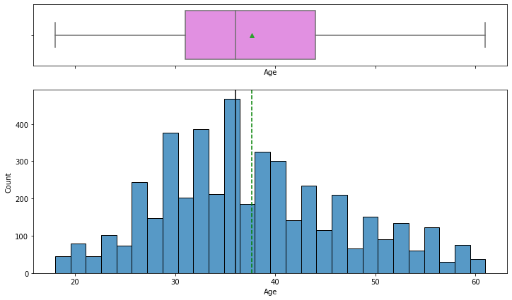

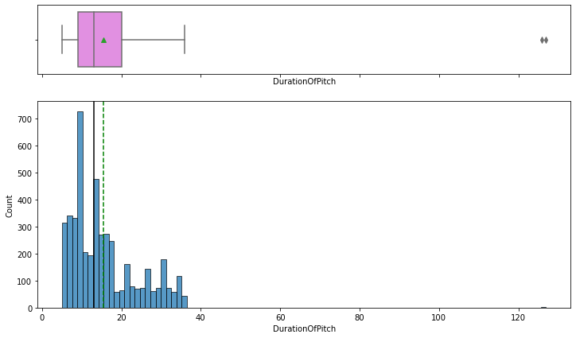

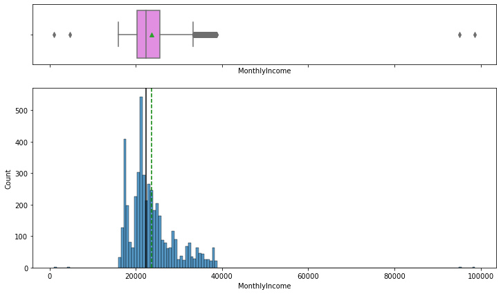

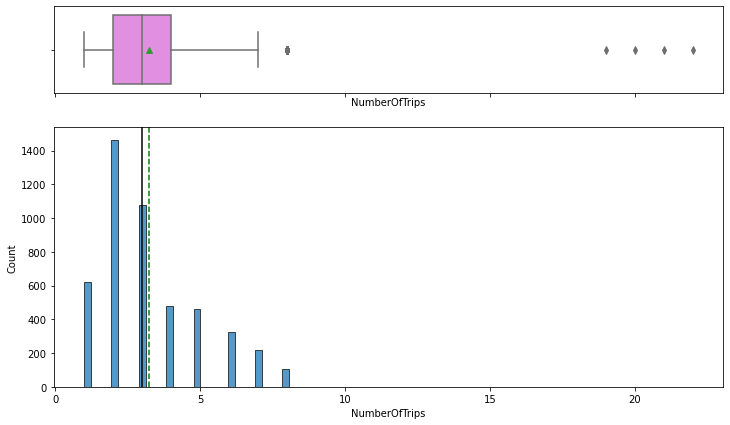

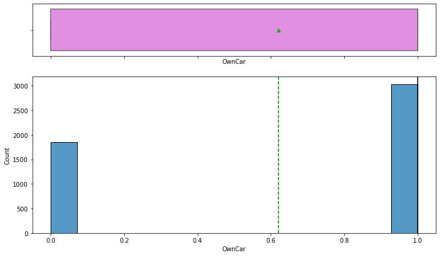

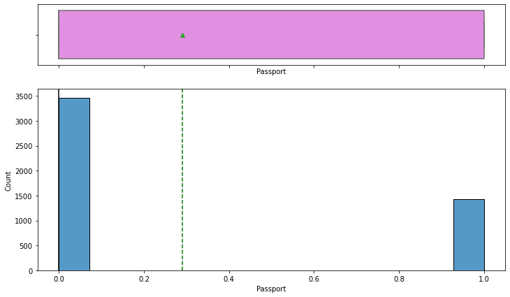

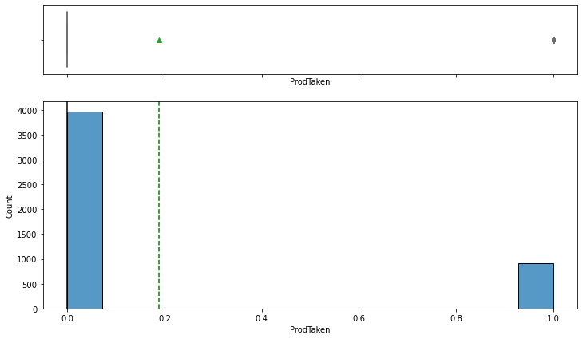

```python
#For every column in the dataframe that has a numerical datatype, show histogram and box plot
for colname in (data.columns[data.dtypes == 'int64'] | data.columns[data.dtypes == 'float64']):
    histogram_boxplot(data, colname)
```

#### Creating barplot for categorical data

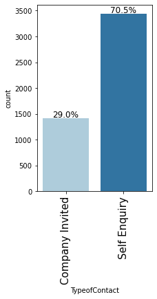

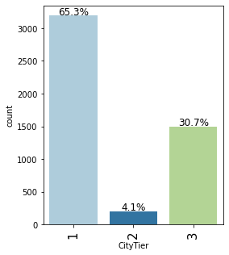

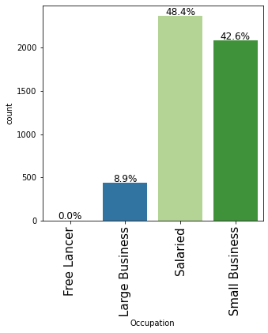

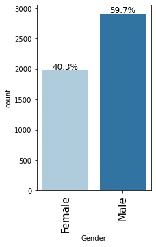

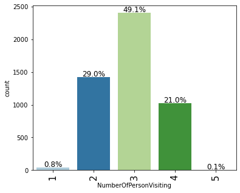

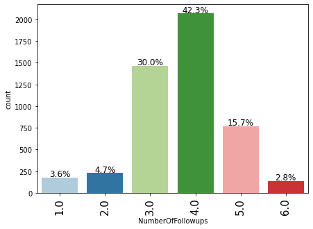

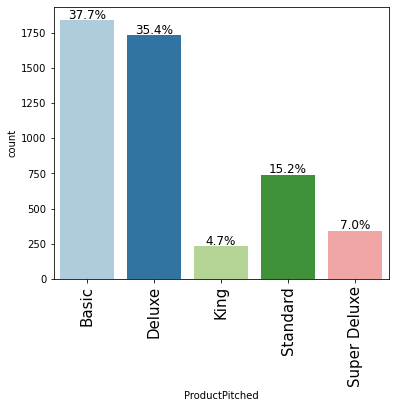

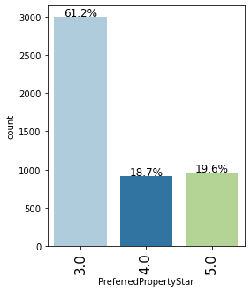

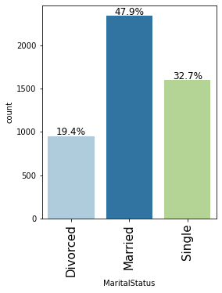

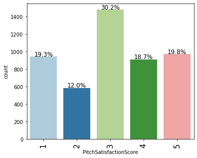

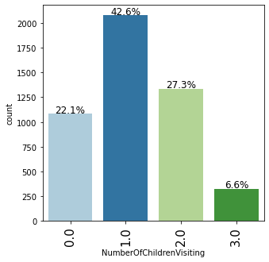

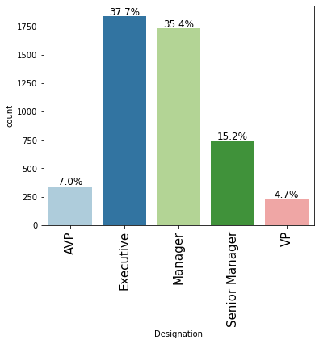

```python
#For every column in the dataframe that has a categorical or object datatype, show distribution plot
#The unique values will be shown only if they are less than 20
for colname in data.columns[data.dtypes == 'category'] | data.columns[data.dtypes == 'object']:
    labeled_barplot(data, colname, perc=True)
```

1. TypeofContact has 2 values. 71% of the customers were contacted through 'Self Enquiry' while 29% of the customers were contacted through Company Invitation.
2. There are 3 CityTiers. Most customers are from CityTier1 with 65.3%. There are 30.7% customers who are from CityTier 3 and only 4.1% are from CityTier 2
3. The customers have 4 different types of Occupation. Most of the customers (48.4%) are salaried. 42.6% are part of small business. Only 8.9% are part of Large Business. Very few are free Lancers
4. Most of the customers are males with 59.7 %. There are 40.3% females.
5. Most customers (49.1%) have 3 as numberOfPersonVisiting. Then 29% have 2, followed by 4 at 21%. Less than 1% have NumberOfPersonVisiting as 1 and 5.
6. 42.3% of the customers had 4 followups. then 30% had 3 followups. and 15.7% had 5 followups.
7. The most product pitched is 'Basic' with 38%. Then its 'Deluxe' with 35.4%. Followed by Standard at 15%, then Super Deluxe at 7% and finally King at 4.7%
8. 61.2% of the customers have 3 as their PreferredPropertyStar. approximately 20% of the customers have PreferredPropertyStar as 4 and 5.
9. MaritalStatus has 3 categories. Most of the customers are married at 48%. 33% are Single and 19.4% are Divorced.
10. The most common PitchSatisfactionScore is 3 with 30% of the Customers having a PitchSatisfactionScore of 3. This is followed by 5 with 20% of the customers. Then 1 with 19.3% of the customers. Followed closely by 4 and only 12% of the customers had a PitchSatisfactionScore of 2.
11. The most common NumberOfChildrenVisiting is 1 with 42.6% of the customers. Then 2 children with 27.3% of the customers. Followed by no children visiting at 22.1% of the customers. Finally only 6.6% of the customers have 3 NumberOfChildrenVisiting.
12. Designation has 5 categories. Most of the customers are Executives with 37.7%. Followed by Manager at 35.4%. Senior Manager is next at 15.2%. AVP is 7% and VP is 4.7%.

## Bivariate Analysis

#### Looking at the relationship between numerical variables using pair plots and heat map

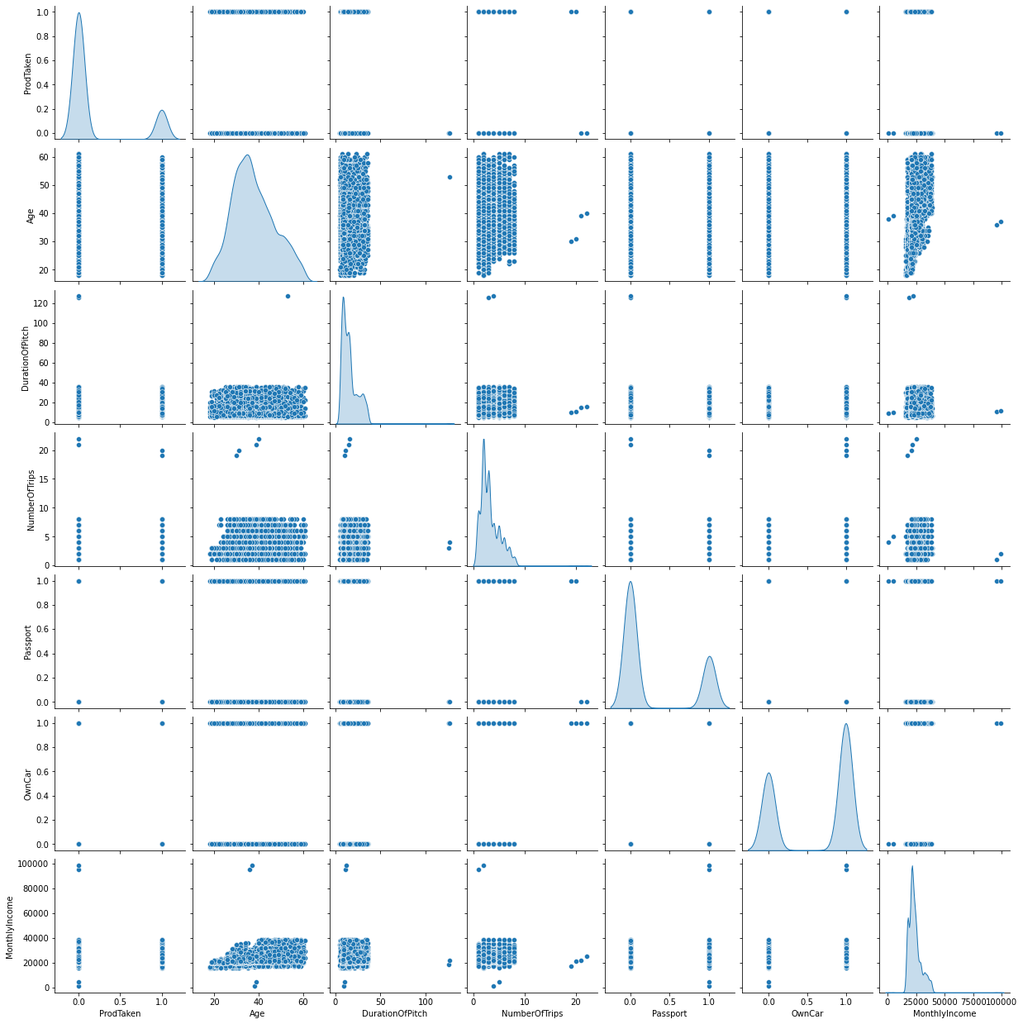

```python
sns.pairplot(data, diag_kind="kde")
```

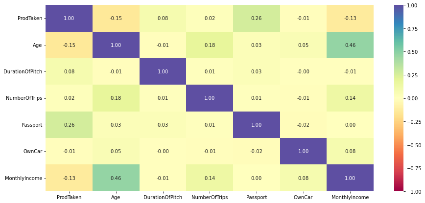

```python
correlation = data.corr()
plt.figure(figsize=(15, 7))
sns.heatmap(correlation, annot=True, vmin=-1, vmax=1, fmt=".2f", cmap="Spectral")
plt.show()
```

Age and Income show some correlation. None of the numeric column show any significant correlation with ProdTaken

### Lets look at categorical columns with ProdTaken

```
ProdTaken           0    1   All
TypeofContact
All              3946  917  4863
Self Enquiry     2837  607  3444
Company Invited  1109  310  1419
------------------------------------------------------------------------------------------------------------------------
```

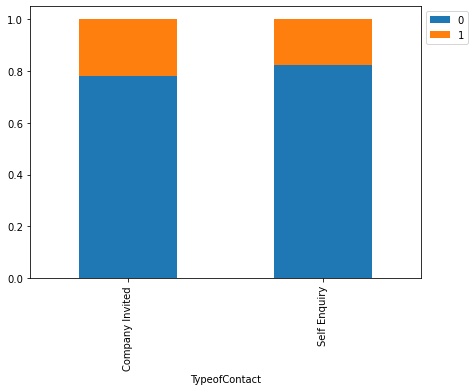

```
ProdTaken     0    1   All
CityTier
All        3968  920  4888
1          2670  520  3190
3          1146  354  1500
2           152   46   198
------------------------------------------------------------------------------------------------------------------------
```

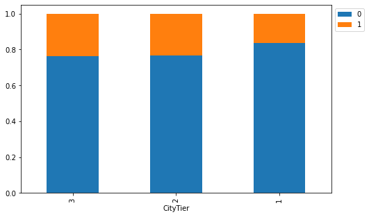

```
ProdTaken          0    1   All
Occupation
All             3968  920  4888
Salaried        1954  414  2368
Small Business  1700  384  2084
Large Business   314  120   434
Free Lancer        0    2     2
------------------------------------------------------------------------------------------------------------------------
```

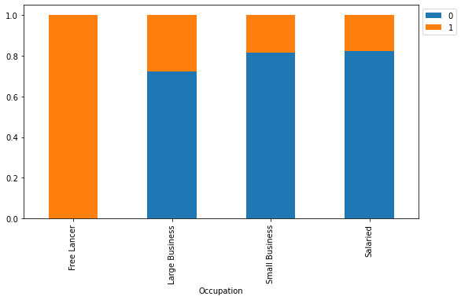

```
ProdTaken     0    1   All
Gender
All        3968  920  4888
Male       2338  578  2916
Female     1630  342  1972
------------------------------------------------------------------------------------------------------------------------
```

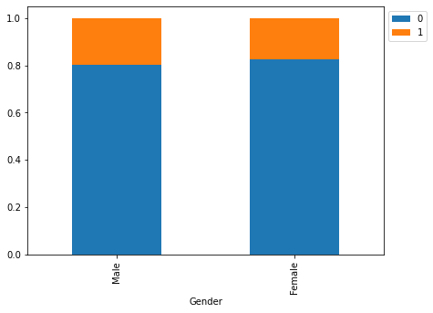

```
ProdTaken                  0    1   All
NumberOfPersonVisiting
All                     3968  920  4888
3                       1942  460  2402
2                       1151  267  1418
4                        833  193  1026
1                         39    0    39
5                          3    0     3
------------------------------------------------------------------------------------------------------------------------
```

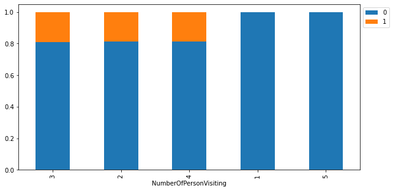

```
ProdTaken             0    1   All
NumberOfFollowups
All                3931  912  4843
4.0                1689  379  2068
3.0                1222  244  1466
5.0                 577  191   768
6.0                  82   54   136
2.0                 205   24   229
1.0                 156   20   176
------------------------------------------------------------------------------------------------------------------------
```

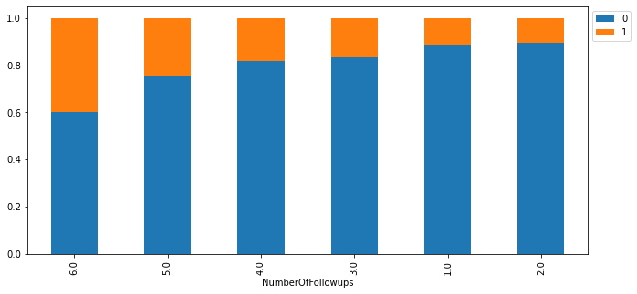

```
ProdTaken          0    1   All
ProductPitched
All             3968  920  4888
Basic           1290  552  1842
Deluxe          1528  204  1732
Standard         618  124   742
King             210   20   230
Super Deluxe     322   20   342
------------------------------------------------------------------------------------------------------------------------
```

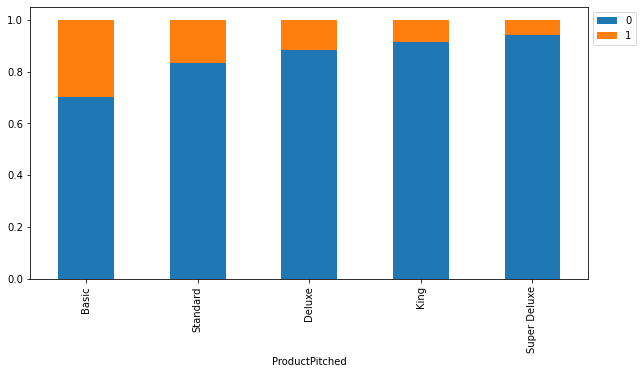

```
ProdTaken                 0    1   All
PreferredPropertyStar
All                    3948  914  4862
3.0                    2511  482  2993
5.0                     706  250   956
4.0                     731  182   913
------------------------------------------------------------------------------------------------------------------------
```

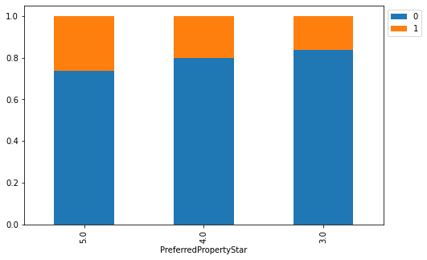

```
ProdTaken         0    1   All
MaritalStatus
All            3968  920  4888
Single         1128  470  1598
Married        2014  326  2340
Divorced        826  124   950
------------------------------------------------------------------------------------------------------------------------
```

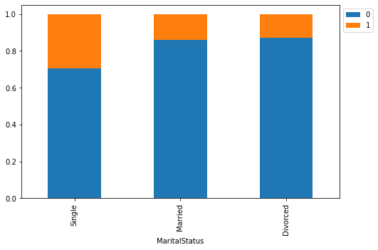

```
ProdTaken                  0    1   All
PitchSatisfactionScore
All                     3968  920  4888
3                       1162  316  1478
5                        760  210   970
4                        750  162   912
1                        798  144   942
2                        498   88   586
------------------------------------------------------------------------------------------------------------------------
```

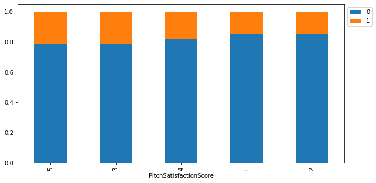

```
ProdTaken                    0    1   All
NumberOfChildrenVisiting
All                       3909  913  4822
1.0                       1688  392  2080
2.0                       1082  253  1335
0.0                        880  202  1082
3.0                        259   66   325
------------------------------------------------------------------------------------------------------------------------
```

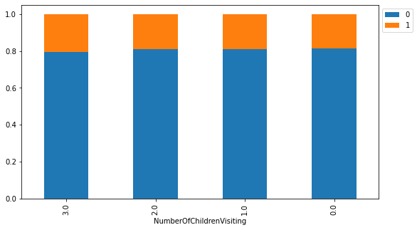

```
ProdTaken          0    1   All
Designation
All             3968  920  4888
Executive       1290  552  1842
Manager         1528  204  1732
Senior Manager   618  124   742
AVP              322   20   342
VP               210   20   230
------------------------------------------------------------------------------------------------------------------------
```

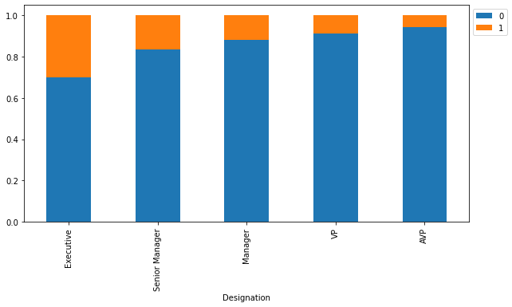

```python
#For every category column print a countplot with category and price to see how they are related.
for colname in (data.columns[data.dtypes == 'category']):
    stacked_barplot(data, colname, 'ProdTaken')
```